# Perform Concentration Response Analysis of MIE Predictions

3/13/2025

This notebook uses the tcplfit2 package to perform a concentration response analysis of MIE predictions generated by MIEML trained high performance classifiers

## Data Import

Import model predictions generated in notebook 4

```r
MIE_predictions <- readRDS(file = "../data/MIE_predictions.rds")
```

Import model performace summaries generated in notebook 3

```r
model_performance <- read.csv(file = "../data/classifier_performance_summary.csv", header = TRUE)
```

## Evaluate Distribution of DMSO predictions

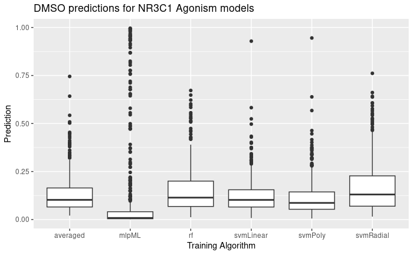

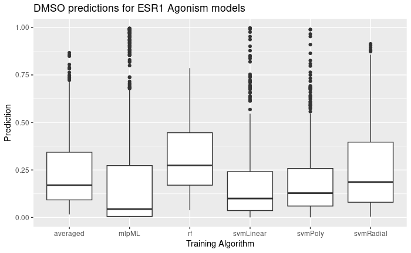

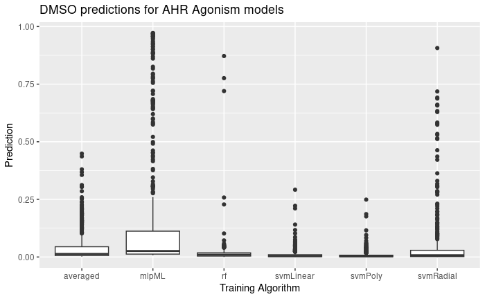

```r
library(ggplot2)
library(plyr)
library(data.table)
#load mieml_httrpl functions
source("../scripts/ML_functions_HTTr.R")

#initialize list to accept plot objects
plot_list <- list()

#subset down MIE predictions to just those from DMSO (vehicle control) wells
DMSO_predictions <- MIE_predictions[MIE_predictions$chem_id == "DMSO" & !is.na(MIE_predictions$chem_id),]

for (i in unique(DMSO_predictions$target_name)){
  # i = unique(low_dose_predictions$target_name)[2]
  temp_data = data.table(DMSO_predictions[DMSO_predictions$target_name == i,])

  averaged_preds <-temp_data[,. (pred = mean(pred)), by = .(target_name, dose_level, sample_id)]
  averaged_preds$model_name <- "averaged"

  temp_data <- rbind.fill(temp_data, averaged_preds)


plot_list[[paste0("DMSO_pred_plot_", i)]]  <-  ggplot(data = temp_data, aes(x=as.factor(model_name), y=pred)) +
      ggtitle(label = paste0("DMSO predictions for ",make_annotations_pretty(i), " models")) +
      geom_boxplot() +
      xlab("Training Algorithm") +
  ylab("Prediction") +
      theme(legend.position="none")

  print(plot_list[[paste0("DMSO_pred_plot_", i)]])
}
```

print all of the DMSO predictions together in a combined plot

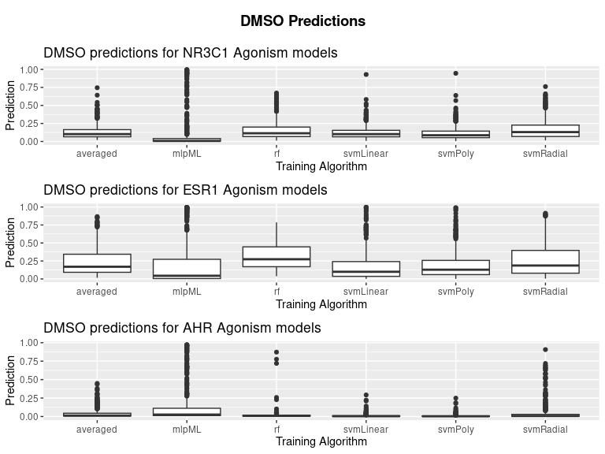

```r
library(cowplot)
title <- ggdraw() + draw_label("DMSO Predictions", fontface='bold')

plots <- plot_grid(

  plot_list[[1]],
  plot_list[[2]],
  plot_list[[3]],
          ncol = 1,
          nrow = 3
)

print(
  plot_grid(title, plots, ncol=1, rel_heights=c(0.1, 1))
  )
```

Save DMSO prediction plot

```r
tiff(filename = "../figures/DMSO_predictions.tiff", height = 6, width = 8, units = "in", res = 300)
print(
  plot_grid(title, plots, ncol=1, rel_heights=c(0.1, 1))
  )
dev.off()
```

## Concentration Response Analysis of Exemplar Chemicals

```r
library(tcplfit2)

#initialize dataframe to catch tcplfit2 results
exemplar_fits <- data.frame()

#step through each target
for (temp_target in unique(MIE_predictions$target_name)){
  #step through each model
  for (temp_model in unique(MIE_predictions[MIE_predictions$target_name == temp_target,]$model_name)){
  message("Analyzing data for MIE: ", temp_target, " with algorithm: ",temp_model)

  #subset predictions down to only those associated with this classifier
  by_model <- MIE_predictions[MIE_predictions$target_name == temp_target & MIE_predictions$model_name == temp_model,]

  #split off DMSO predictions
  baseline_data <- by_model[by_model$chem_id == "DMSO" & by_model$stype == "vehicle control" & !is.na(by_model$chem_id),]

  #calculate baseline metrics from baseline data for this model
  onesd <- sd(baseline_data$pred)
  cutoff = 2*mad(baseline_data$pred)
  bmed <- median(baseline_data$pred)

  #for now, only do conc resp analysis for exemplar chemicals - subset data down to just those for the exemplar chemical
  by_model <- by_model[by_model$exemplar_chemical_for_MIE == 1,]

  #extract relevant information from this dataframe and format as a list for concentration response analysis with tcplfit2
  conc <- list(by_model$conc)
  resp <- list(by_model$pred)
  row = list(conc = conc, resp = resp, bmed = bmed, cutoff = cutoff, onesd = onesd,name=unique(by_model$chem_name)[1])

  #run tcplfit2 based concentration response analysis
  res <- concRespCore(row,fitmodels = c("cnst", "hill", "poly1", "poly2", "pow", "exp2", "exp3", "exp4", "exp5"),conthits = TRUE, do.plot=F)

  #add useful information to output
  res$target_name <- temp_target
  res$model_name <- temp_model
 exemplar_fits <-  rbind(res, exemplar_fits)
  }
}
```

```
Analyzing data for MIE: NR3C1_Positive with algorithm: svmRadial
Analyzing data for MIE: NR3C1_Positive with algorithm: svmPoly
Analyzing data for MIE: NR3C1_Positive with algorithm: svmLinear
Analyzing data for MIE: NR3C1_Positive with algorithm: rf
Analyzing data for MIE: NR3C1_Positive with algorithm: mlpML
Analyzing data for MIE: ESR1_Positive_group with algorithm: svmRadial
Analyzing data for MIE: ESR1_Positive_group with algorithm: svmPoly
Analyzing data for MIE: ESR1_Positive_group with algorithm: svmLinear
Analyzing data for MIE: ESR1_Positive_group with algorithm: rf
Analyzing data for MIE: ESR1_Positive_group with algorithm: mlpML
Analyzing data for MIE: AHR_Positive with algorithm: svmRadial
Analyzing data for MIE: AHR_Positive with algorithm: svmPoly
Analyzing data for MIE: AHR_Positive with algorithm: svmLinear
Analyzing data for MIE: AHR_Positive with algorithm: rf
Analyzing data for MIE: AHR_Positive with algorithm: mlpML
```

Add an “assay” field by combining the target name and model name fields + tcplfit2 plotting functions use the assay field to generate plot titles

```r
exemplar_fits$assay <- paste0(make_annotations_pretty(exemplar_fits$target_name), " ", exemplar_fits$model_name)
```

Plot results from concentration response analysis of exemplar chemicals

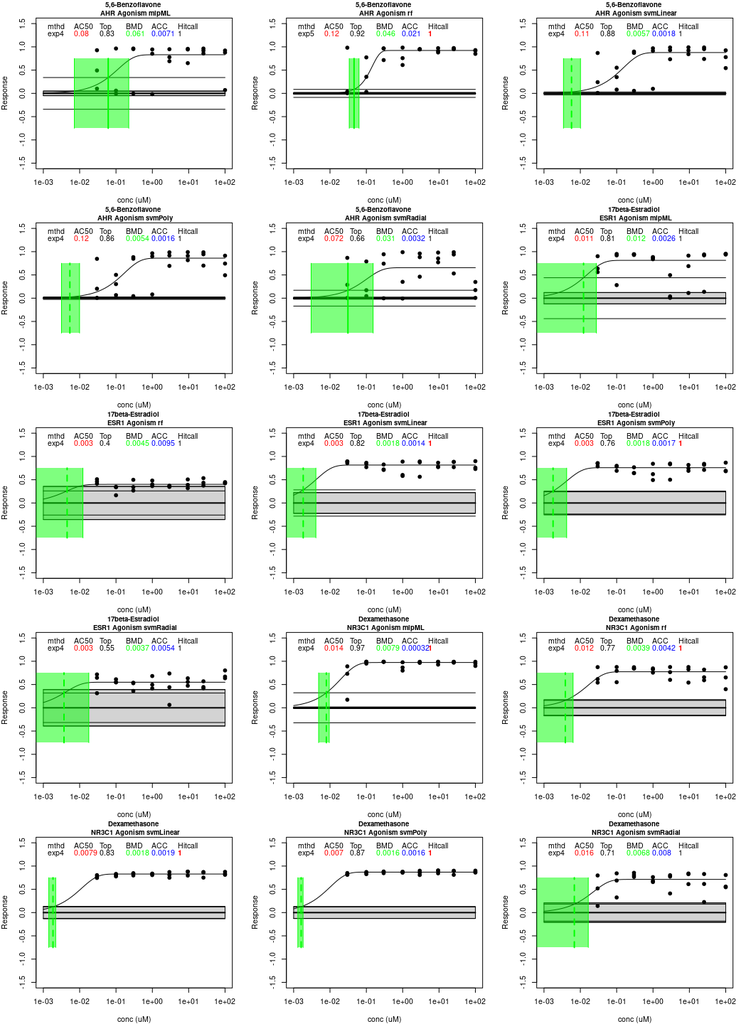

```r
oldpar <- par(no.readonly = TRUE)
on.exit(par(oldpar))
par(mfrow=c(5,3),mar=c(4,4,2,2))

for (i in 1:nrow(exemplar_fits)){
concRespPlot(exemplar_fits[i,],ymin=-1.5,ymax=1.5)
}
```

Save this figure to disk

```r
tiff(filename = "../figures/exemplar_chemical_fits.tiff", height = 15, width = 11, units = "in", res = 300)

oldpar <- par(no.readonly = TRUE)
on.exit(par(oldpar))
par(mfrow=c(5,3),mar=c(4,4,2,2))

print(
for (i in 1:nrow(exemplar_fits)){
concRespPlot(exemplar_fits[i,],ymin=-1.5,ymax=1.5)
}
  )
```

```r
dev.off()
```

Merge exemplar chemical hitcall information with classifier performance summary

```r
#subset columns
model_performance_revised <- model_performance[c("target_name","model_name","internal_accuracy","holdout_accuracy","chemical_targets","target_members", "holdout_members","n_nulls", "int_acc_emp_pval", "hold_acc_emp_pval", "passed_EST")]

#create temp "assay" column in model_performance_revised to merge exemplar data
model_performance_revised$assay <- paste0(make_annotations_pretty(model_performance_revised$target_name), " ", model_performance_revised$model_name)

model_performance_revised <- merge(model_performance_revised, exemplar_fits[c("assay","name", "hitcall")], by = "assay", all.x = TRUE)

#make annotations pretty
model_performance_revised$target_name <- make_annotations_pretty(model_performance_revised$target_name)

#multiply the "target members" column by two so it's actually the number of training data profiles - change the column name later
model_performance_revised$target_members <- model_performance_revised$target_members * 2

names(model_performance_revised)
```

```
 [1] "assay"             "target_name"       "model_name"        "internal_accuracy" "holdout_accuracy"
 [6] "chemical_targets"  "target_members"    "holdout_members"   "n_nulls"           "int_acc_emp_pval"
[11] "hold_acc_emp_pval" "passed_EST"        "name"              "hitcall"
```

Pretty up column names for export

```r
model_performance_revised$assay <- NULL
names(model_performance_revised) <- c("MIE", "Training Algorithm", "Internal Accuracy", "Holdout Accuracy", "#Training Chemicals", "#Training Profiles", "#Holdout Profiles", "#Null Models Trained", "Internal Accuracy EST P-val", "Holdout Accuracy EST P-val", "Passed EST", "Exemplar Chemical", "Exemplar Hitcall")
```

save model_performance_revised to disk

```r
write.csv(x = model_performance_revised, file = "../data/classifier_performance_summary_with_exemplar_hitcalls.csv")
```

filter high performance classifiers by determining if their corresponding exemplar chemical had a positive hitcall

```r
high_performance_classifiers <- model_performance[model_performance$passed_EST == "yes",]

confirmed_high_performance_classifiers <- data.frame()
for (i in 1:nrow(high_performance_classifiers)){
  model_name <- high_performance_classifiers[i,]$model_name
  target_name <- high_performance_classifiers[i,]$target_name

  relevant_exemplar_fit <- exemplar_fits[exemplar_fits$target_name == target_name & exemplar_fits$model_name == model_name,]

  if (relevant_exemplar_fit$hitcall >= 0.9){
    confirmed_high_performance_classifiers <- rbind(high_performance_classifiers[i,], confirmed_high_performance_classifiers)
  }
}
```

view confirmed high performance classifiers

```r
confirmed_high_performance_classifiers
```

|  | X | model_name | target_name | internal_accuracy | holdout_accuracy | holdout_auroc | target_members | holdout_members | time.elapsed | support_level | chemical_targets | model_path | mean_permuted_internal_accuracy | mean_permuted_holdout_accuracy | mean_permuted_holdout_auroc | int_acc_emp_pval | hold_acc_emp_pval | hold_auroc_emp_pval | permutation_path | n_nulls | passed_EST | pretty_MIE_name |
| --- | --- | --- | --- | --- | --- | --- | --- | --- | --- | --- | --- | --- | --- | --- | --- | --- | --- | --- | --- | --- | --- | --- |
| 42 | 42 | svmRadial | NR3C1_Positive | 0.8256362 | 0.8695652 | 0.9773157 | 115 | 46 | 00:00:33 | 3 | 6 | ../data/model_files/analysis_3_8_2025/NR3C1_Positive/NR3C1_Positive_svmRadial.rds | 0.7410820 | 0.7584783 | 0.8368998 | 0.035 | 0.045 | 0.000 | ../data/model_files/analysis_3_8_2025/NR3C1_Positive/NR3C1_Positive_permutation_results.rds | 200 | yes | NR3C1 Agonism |
| 41 | 41 | svmPoly | NR3C1_Positive | 0.8806306 | 0.9130435 | 0.9565217 | 115 | 46 | 00:01:06 | 3 | 6 | ../data/model_files/analysis_3_8_2025/NR3C1_Positive/NR3C1_Positive_svmPoly.rds | 0.7862968 | 0.7914130 | 0.8617108 | 0.025 | 0.045 | 0.040 | ../data/model_files/analysis_3_8_2025/NR3C1_Positive/NR3C1_Positive_permutation_results.rds | 200 | yes | NR3C1 Agonism |
| 40 | 40 | svmLinear | NR3C1_Positive | 0.8644144 | 0.9130435 | 0.9546314 | 115 | 46 | 00:00:13 | 3 | 6 | ../data/model_files/analysis_3_8_2025/NR3C1_Positive/NR3C1_Positive_svmLinear.rds | 0.7798489 | 0.7932609 | 0.8662665 | 0.045 | 0.035 | 0.040 | ../data/model_files/analysis_3_8_2025/NR3C1_Positive/NR3C1_Positive_permutation_results.rds | 200 | yes | NR3C1 Agonism |
| 39 | 39 | rf | NR3C1_Positive | 0.8916943 | 0.9130435 | 0.9810964 | 115 | 46 | 00:01:11 | 3 | 6 | ../data/model_files/analysis_3_8_2025/NR3C1_Positive/NR3C1_Positive_rf.rds | 0.7391157 | 0.7519565 | 0.8262665 | 0.005 | 0.015 | 0.005 | ../data/model_files/analysis_3_8_2025/NR3C1_Positive/NR3C1_Positive_permutation_results.rds | 200 | yes | NR3C1 Agonism |
| 38 | 38 | mlpML | NR3C1_Positive | 0.8369369 | 0.8478261 | 0.9187146 | 115 | 46 | 00:04:23 | 3 | 6 | ../data/model_files/analysis_3_8_2025/NR3C1_Positive/NR3C1_Positive_mlpML.rds | 0.6915497 | 0.6963043 | 0.7716163 | 0.005 | 0.040 | 0.025 | ../data/model_files/analysis_3_8_2025/NR3C1_Positive/NR3C1_Positive_permutation_results.rds | 200 | yes | NR3C1 Agonism |
| 30 | 30 | svmRadial | ESR1_Positive_group | 0.7935484 | 0.8289474 | 0.8954294 | 193 | 76 | 00:00:59 | 3 | 20 | ../data/model_files/analysis_3_8_2025/ESR1_Positive_group/ESR1_Positive_group_svmRadial.rds | 0.6829355 | 0.6962500 | 0.7606683 | 0.005 | 0.015 | 0.010 | ../data/model_files/analysis_3_8_2025/ESR1_Positive_group/ESR1_Positive_group_permutation_results.rds | 200 | yes | ESR1 Agonism |
| 29 | 29 | svmPoly | ESR1_Positive_group | 0.8774194 | 0.8552632 | 0.9023546 | 193 | 76 | 00:01:58 | 3 | 20 | ../data/model_files/analysis_3_8_2025/ESR1_Positive_group/ESR1_Positive_group_svmPoly.rds | 0.7019194 | 0.7021711 | 0.7605644 | 0.000 | 0.010 | 0.020 | ../data/model_files/analysis_3_8_2025/ESR1_Positive_group/ESR1_Positive_group_permutation_results.rds | 200 | yes | ESR1 Agonism |
| 28 | 28 | svmLinear | ESR1_Positive_group | 0.8709677 | 0.8815789 | 0.9030471 | 193 | 76 | 00:00:22 | 3 | 20 | ../data/model_files/analysis_3_8_2025/ESR1_Positive_group/ESR1_Positive_group_svmLinear.rds | 0.6942097 | 0.7059211 | 0.7672576 | 0.000 | 0.005 | 0.015 | ../data/model_files/analysis_3_8_2025/ESR1_Positive_group/ESR1_Positive_group_permutation_results.rds | 200 | yes | ESR1 Agonism |
| 27 | 27 | rf | ESR1_Positive_group | 0.8096774 | 0.7894737 | 0.8795014 | 193 | 76 | 00:03:11 | 3 | 20 | ../data/model_files/analysis_3_8_2025/ESR1_Positive_group/ESR1_Positive_group_rf.rds | 0.6700645 | 0.6691447 | 0.7312864 | 0.000 | 0.040 | 0.025 | ../data/model_files/analysis_3_8_2025/ESR1_Positive_group/ESR1_Positive_group_permutation_results.rds | 200 | yes | ESR1 Agonism |
| 26 | 26 | mlpML | ESR1_Positive_group | 0.7193548 | 0.7236842 | 0.8227147 | 193 | 76 | 00:06:49 | 3 | 20 | ../data/model_files/analysis_3_8_2025/ESR1_Positive_group/ESR1_Positive_group_mlpML.rds | 0.6267742 | 0.6237500 | 0.6755817 | 0.010 | 0.080 | 0.025 | ../data/model_files/analysis_3_8_2025/ESR1_Positive_group/ESR1_Positive_group_permutation_results.rds | 200 | yes | ESR1 Agonism |

[output cut: 5 more lines]

what’s the median internal and holdout accuracy of these CHPCs

```r
median(confirmed_high_performance_classifiers$internal_accuracy)
```

```
[1] 0.8774194
```

```r
median(confirmed_high_performance_classifiers$holdout_accuracy)
```

```
[1] 0.8888889
```

subset MIE_predictions down to only those generated from high performance classifiers

```r
#generate a filter column that is just the concatenated target and algorithm name to allow for filtering
MIE_predictions$filter <- paste0(MIE_predictions$target_name, MIE_predictions$model_name)
confirmed_high_performance_classifiers$filter <- paste0(confirmed_high_performance_classifiers$target_name,confirmed_high_performance_classifiers$model_name)

confirmed_MIE_predictions <- MIE_predictions[MIE_predictions$filter %in% confirmed_high_performance_classifiers$filter,]
```

## Run Concentration Response Analysis on Confirmed High Performance Classifiers

This step will perform concentration response analysis independently for each unique set of: + Confirmed High performance Classifiers + Chemical IDs

This may involve calling concRespCore several thousand times. To speed this up, recommend parallelizing the concentration response step. To that end, declare the number of cores to be used in parallelization:

```r
CORES = 20
```

Perform parallelized concentration response analysis

```r
library(doParallel)
library(foreach)

#initialize dataframe to catch tcplfit2 results
all_fits <- data.frame()

for (i in 1:nrow(confirmed_high_performance_classifiers)){
  #i = 1
  message("Analyzing data for MIE: ", confirmed_high_performance_classifiers[i,]$target_name, " with ", confirmed_high_performance_classifiers[i,]$model_name, " model")

  #subset data to only the predictions generated by this classifier
  by_model <- confirmed_MIE_predictions[confirmed_MIE_predictions$target_name == confirmed_high_performance_classifiers[i,]$target_name & confirmed_MIE_predictions$model_name == confirmed_high_performance_classifiers[i,]$model_name,]

  #parse out predictions from DMSO control wells
  baseline_data <- by_model[by_model$chem_id == "DMSO" & by_model$stype == "vehicle control" & !is.na(by_model$chem_id),]

  #calculate baseline metrics from baseline data for this classifier
  onesd <- sd(baseline_data$pred)
  cutoff = 2*mad(baseline_data$pred)
  bmed <- median(baseline_data$pred)

  #register cores to enable multithreaded analysis
  registerDoParallel(cores=CORES)

  #use foreach to paralleleize concentration response analysis of MIE predictions for each chemical
  fit_catcher <- foreach(k=1:length(unique(na.omit(by_model$chem_id))), .combine = 'rbind', .init = data.frame()) %dopar% {

  chem_id = unique(na.omit(by_model$chem_id))[k]

  by_chemical <- by_model[by_model$chem_id == chem_id & !is.na(by_model$chem_id),]

  conc <- list(by_chemical$conc)
  resp <- list(by_chemical$pred)
  row = list(conc = conc, resp = resp, bmed = bmed, cutoff = cutoff, onesd = onesd,name=unique(by_chemical$chem_name)[1])

  res <- concRespCore(row,fitmodels = c("cnst", "hill", "poly1", "poly2", "pow", "exp2", "exp3", "exp4", "exp5"),conthits = TRUE, do.plot=F)
  res$target_name <- confirmed_high_performance_classifiers[i,]$target_name
  res$model_name <- confirmed_high_performance_classifiers[i,]$model_name
  res$chem_id <- chem_id
  res$is_MIE_active_training_chem <- by_chemical$is_MIE_active_training_chem[1]
  res$is_MIE_inactive_training_chem <- by_chemical$is_MIE_inactive_training_chem[1]
  res$exemplar_chemical_for_MIE <- by_chemical$exemplar_chemical_for_MIE[1]
  res$MIE_linkage_support_level <- by_chemical$MIE_linkage_support_level[1]
  res
  }
 all_fits <-  rbind(fit_catcher, all_fits)
}
```

```
Analyzing data for MIE: NR3C1_Positive with svmRadial model
Analyzing data for MIE: NR3C1_Positive with svmPoly model
Analyzing data for MIE: NR3C1_Positive with svmLinear model
Analyzing data for MIE: NR3C1_Positive with rf model
Analyzing data for MIE: NR3C1_Positive with mlpML model
Analyzing data for MIE: ESR1_Positive_group with svmRadial model
Analyzing data for MIE: ESR1_Positive_group with svmPoly model
Analyzing data for MIE: ESR1_Positive_group with svmLinear model
Analyzing data for MIE: ESR1_Positive_group with rf model
Analyzing data for MIE: ESR1_Positive_group with mlpML model
Analyzing data for MIE: AHR_Positive with svmRadial model
Analyzing data for MIE: AHR_Positive with svmPoly model
Analyzing data for MIE: AHR_Positive with svmLinear model
Analyzing data for MIE: AHR_Positive with rf model
Analyzing data for MIE: AHR_Positive with mlpML model
```

## Export Concentration Response Analysis Results to Disk

Import sample metadata to add chemical metadata to tcplfit2 output

```r
httr_metadata <- readRDS("../data/mongodb_dump/httr_metadata.rds")

chem_info <- unique(httr_metadata[c("chem_id", "dtxsid")])

all_fits <- merge(all_fits, chem_info, by = "chem_id")
```

Save to disk

```r
saveRDS(all_fits, file = "../data/CHPC_conc_resp_analysis_results.rds")
```